# 影響學生及格的因素：二元 logistic 迴歸分析

**結論摘要**

本分析以二元 logistic 迴歸（§4）探討讀書時間（studytime）、被當次數（failures）、想不想讀大學（higher）與性別（sex）對葡萄牙文科是否及格的影響，共 649 位學生（及格 549 人）。最初的模型 A 把 failures 當數值分數，但模型比較顯示把 failures 當類別的模型 B 明顯較好（LR = 9.53，df = 2，P = 0.009；AIC 465.44 對 470.97），代表「每多被當一次效果相同」的等距假設不成立，因此以模型 B 為最終模型。

模型 B 中，四個變數合起來有顯著關聯（LR = 106.35，df = 6，P < 0.001），AUC = 0.800。在其他變數固定時，被當次數影響最大（LR = 49.04，df = 3，P < 0.001），而且主要是「有沒有被當過」的差別：相對於被當 0 次，被當 1、2、3 次的及格勝算比分別為 0.164、0.158、0.099，預測及格機率從 0.927 降到 0.674、0.666、0.555。被當 2 次和 3 次各只有 16 人和 14 人，信賴區間很寬，1 到 3 次之間的高低順序並不明確。

想讀大學的學生及格勝算是不想讀者的 3.500 倍（95% CI 1.872 – 6.475），預測機率 0.927 對 0.783。讀書時間每多一級，及格勝算乘以 1.400（95% CI 1.011 – 1.980，LR 檢定 P = 0.043），證據較邊緣。性別沒有顯著影響（LR 檢定 P = 0.358）。這是觀察資料，所見為關聯而非因果。

## q1：二元 logistic 迴歸

結果變數 `pass`，成功類別 = pass；n = 649（成功 549）。整體檢定 LR = 96.82，df = 4，P < 0.001。

#### 勝算比

- 其他變數固定時，studytime（每增加 1）：「pass」的勝算乘以 **1.450**（95% CI 1.050 – 2.046）
- 其他變數固定時，failures（每增加 1）：「pass」的勝算乘以 **0.358**（95% CI 0.253 – 0.495）
- 其他變數固定時，higher = yes（相對於 no）：「pass」的勝算乘以 **3.766**（95% CI 2.040 – 6.877）
- 其他變數固定時，sex = M（相對於 F）：「pass」的勝算乘以 **0.848**（95% CI 0.521 – 1.388）

| 項目 | β | SE | 勝算比 | 95% CI（profile likelihood） | Wald P |
| --- | --- | --- | --- | --- | --- |
| studytime（每增加 1） | 0.372 | 0.170 | 1.450 | 1.050 – 2.046 | 0.029 |
| failures（每增加 1） | -1.028 | 0.171 | 0.358 | 0.253 – 0.495 | < 0.001 |
| higher = yes（相對於 no） | 1.326 | 0.309 | 3.766 | 2.040 – 6.877 | < 0.001 |
| sex = M（相對於 F） | -0.164 | 0.249 | 0.848 | 0.521 – 1.388 | 0.509 |

#### 每個變數的概似比檢定（拿掉該變數）

| 變數 | LR | df | P |
| --- | --- | --- | --- |
| studytime | 5.12 | 1 | 0.024 |
| failures | 39.51 | 1 | < 0.001 |
| higher | 17.24 | 1 | < 0.001 |
| sex | 0.43 | 1 | 0.510 |

預測能力：AUC = **0.799**（0.5 = 亂猜、1 = 完美區分）

#### 預測機率（其他變數固定在平均數或最常見類別）

| 變數 | 值 | 預測機率 |
| --- | --- | --- |
| studytime | Q1（1） | 0.861 |
| studytime | Q3（2） | 0.900 |
| failures | 最小值（0） | 0.917 |
| failures | 最大值（3） | 0.335 |
| higher | no（no） | 0.699 |
| higher | yes（yes） | 0.898 |
| sex | F（F） | 0.898 |
| sex | M（M） | 0.881 |

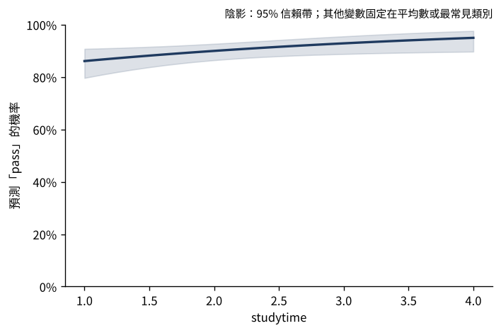

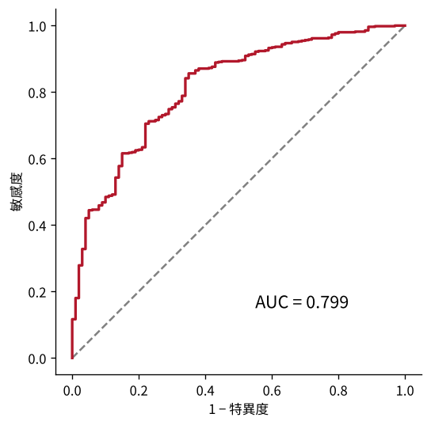

**注意事項**

- `GOF_NOTE` 模型含數值解釋變數，deviance 不能當適合度檢定；要檢查模型，請和更複雜的模型（例如加交互作用）做概似比比較（§5.2.3）。

## q1_compare：比較兩個模型

模型：二元 logistic 迴歸；結果變數 `pass`；n = 649（兩個模型使用同一批資料）。

| 模型 | 解釋變數 | 參數個數 | 對數概似 | AIC |
| --- | --- | --- | --- | --- |
| 模型 A | studytime（數值）、failures（數值）、higher（類別）、sex（類別） | 5 | -230.48 | 470.97 |
| 模型 B | studytime（數值）、failures（類別）、higher（類別）、sex（類別） | 7 | -225.72 | 465.44 |

概似比檢定（A 是 B 的特例）：LR = 9.53，df = 2，P = 0.009

**結論：**P = 0.009，小於 0.05：較複雜的模型 B 明顯比較好，多出來的參數有必要（§5.2）。

AIC 較小的是模型 B。

## q1_cat：二元 logistic 迴歸

結果變數 `pass`，成功類別 = pass；n = 649（成功 549）。整體檢定 LR = 106.35，df = 6，P < 0.001。

#### 勝算比

- 其他變數固定時，studytime（每增加 1）：「pass」的勝算乘以 **1.400**（95% CI 1.011 – 1.980）
- 其他變數固定時，failures = 1（相對於 0）：「pass」的勝算乘以 **0.164**（95% CI 0.091 – 0.295）
- 其他變數固定時，failures = 2（相對於 0）：「pass」的勝算乘以 **0.158**（95% CI 0.052 – 0.484）
- 其他變數固定時，failures = 3（相對於 0）：「pass」的勝算乘以 **0.099**（95% CI 0.028 – 0.319）
- 其他變數固定時，higher = yes（相對於 no）：「pass」的勝算乘以 **3.500**（95% CI 1.872 – 6.475）
- 其他變數固定時，sex = M（相對於 F）：「pass」的勝算乘以 **0.793**（95% CI 0.484 – 1.303）

| 項目 | β | SE | 勝算比 | 95% CI（profile likelihood） | Wald P |
| --- | --- | --- | --- | --- | --- |
| studytime（每增加 1） | 0.337 | 0.171 | 1.400 | 1.011 – 1.980 | 0.049 |
| failures = 1（相對於 0） | -1.809 | 0.299 | 0.164 | 0.091 – 0.295 | < 0.001 |
| failures = 2（相對於 0） | -1.844 | 0.560 | 0.158 | 0.052 – 0.484 | < 0.001 |
| failures = 3（相對於 0） | -2.314 | 0.609 | 0.099 | 0.028 – 0.319 | < 0.001 |
| higher = yes（相對於 no） | 1.253 | 0.316 | 3.500 | 1.872 – 6.475 | < 0.001 |
| sex = M（相對於 F） | -0.232 | 0.252 | 0.793 | 0.484 – 1.303 | 0.357 |

#### 每個變數的概似比檢定（拿掉該變數）

| 變數 | LR | df | P |
| --- | --- | --- | --- |
| studytime | 4.11 | 1 | 0.043 |
| failures | 49.04 | 3 | < 0.001 |
| higher | 14.95 | 1 | < 0.001 |
| sex | 0.85 | 1 | 0.358 |

預測能力：AUC = **0.800**（0.5 = 亂猜、1 = 完美區分）

#### 預測機率（其他變數固定在平均數或最常見類別）

| 變數 | 值 | 預測機率 |
| --- | --- | --- |
| studytime | Q1（1） | 0.902 |
| studytime | Q3（2） | 0.928 |
| failures | 0（0） | 0.927 |
| failures | 1（1） | 0.674 |
| failures | 2（2） | 0.666 |
| failures | 3（3） | 0.555 |
| higher | no（no） | 0.783 |
| higher | yes（yes） | 0.927 |
| sex | F（F） | 0.927 |
| sex | M（M） | 0.909 |

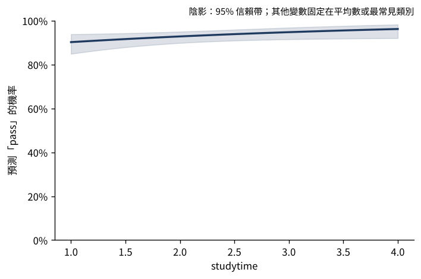

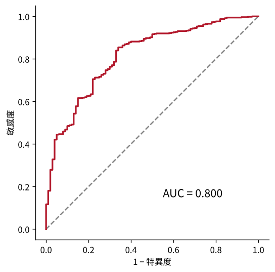

**注意事項**

- `GOF_NOTE` 模型含數值解釋變數，deviance 不能當適合度檢定；要檢查模型，請和更複雜的模型（例如加交互作用）做概似比比較（§5.2.3）。

本報告由 categorical-modeling Skill 的 run_model.py 產生；所有數字都由程式計算。方法依據：Agresti, A. (2019). *An Introduction to Categorical Data Analysis* (3rd ed.). Wiley.